# Computing Assignment V

OMG

# Preliminary Questions

**1. Is the t-test procedure consistent?**

$$t = \frac{\hat{\beta}-\beta_o}{s(\hat\beta)} = \frac{\hat{\beta}-\beta}{s(\hat\beta)} + \frac{\beta-\beta_o}{s(\hat\beta)}$$
If $\beta=0$, this converges in distribution to $\sim \mathrm{N}(0,1)$. Hence $P(|T(\hat\beta)|>Z_{\alpha/2}=1-\alpha$ as N goes to infinity.
**The test procedure is not consistent.**

If $\beta > 0$, this converges in distribution to $\sim \mathrm{N}(0,1) + \infty$. Hence $P(|T(\hat\beta))|>Z_{\alpha/2}=1$ as N goes to infinity.  
**The test procedure is consistent.**

**2. Is the post-test estimator for $\alpha$ consistent?**

**Yes.** If if $\beta=0$, we use the restricted model and $\hat{\alpha} \rightarrow \alpha$ assuming that $E[e|X_1]=0$. If $\beta \neq0$, then we use the unrestricted model and $\hat{\alpha} \rightarrow \alpha$ given the error term in the unrestricted model is not correlated with $X_1$.

# Variances of Estimated Alphas

| type | 50 | 100 | 150 | 200 |
| --- | --- | --- | --- | --- |
| unrest | 0.044 | 0.021 | 0.012 | 0.010 |
| rest | 0.021 | 0.011 | 0.007 | 0.005 |
| post | 0.029 | 0.014 | 0.008 | 0.007 |

In class we saw that the restricted ols is more efficient when the restriction is correct ($\beta=0$), which we observe in the simulations.

The variance under the post-test estimator is between the restricted and unrestricted variances. The post-test estimator variance seems to be converging quickly to the restricted estimator variance as sample size increases. In the limit we do not expect full convergence as 5% the test will be wrong.

# Bias of the Three Estimators

Table 3: bias of estimators beta not 0

| beta | type | 50 | 100 | 150 | 200 |
| --- | --- | --- | --- | --- | --- |
| 0.16 | unrest | 0.005 | -0.004 | 0.003 | -0.006 |
| 0.16 | rest | 0.118 | 0.112 | 0.115 | 0.109 |
| 0.16 | post | 0.080 | 0.061 | 0.056 | 0.040 |
| 0.24 | unrest | -0.004 | 0.002 | -0.001 | 0.000 |
| 0.24 | rest | 0.165 | 0.168 | 0.167 | 0.165 |
| 0.24 | post | 0.087 | 0.070 | 0.043 | 0.032 |
| 0.50 | unrest | -0.006 | 0.000 | 0.001 | 0.001 |
| 0.50 | rest | 0.348 | 0.352 | 0.354 | 0.351 |
| 0.50 | post | 0.054 | 0.009 | 0.002 | 0.001 |

The unrestricted estimator is unbiased, while the restricted and post-test estimators are biased. However the post-test estimator is consistent, as discussed previously.

Post-test bias is getting smaller and smaller as the sample size increases and as the true beta moves away from $\beta_o$, the bias decreases to zero, suggesting the power of the test is good.

# Alpha Contained in the CI

Table 4: Average times that alpha is in CI

| beta | type | 50 | 100 | 150 | 200 |
| --- | --- | --- | --- | --- | --- |
| 0.00 | unrest | 0.949 | 0.947 | 0.961 | 0.952 |
| 0.00 | rest | 0.952 | 0.940 | 0.953 | 0.951 |
| 0.00 | post | 0.934 | 0.926 | 0.942 | 0.936 |
| 0.16 | unrest | 0.952 | 0.950 | 0.950 | 0.951 |
| 0.16 | rest | 0.867 | 0.810 | 0.700 | 0.665 |
| 0.16 | post | 0.866 | 0.826 | 0.758 | 0.766 |
| 0.24 | unrest | 0.948 | 0.945 | 0.952 | 0.954 |
| 0.24 | rest | 0.801 | 0.642 | 0.494 | 0.383 |
| 0.24 | post | 0.824 | 0.744 | 0.756 | 0.751 |
| 0.50 | unrest | 0.946 | 0.948 | 0.954 | 0.958 |
| 0.50 | rest | 0.389 | 0.097 | 0.022 | 0.004 |
| 0.50 | post | 0.769 | 0.910 | 0.950 | 0.958 |

When $\beta = 0$, the post-test contains $\alpha$ in the CI with the least frequency. The restricted and unrestricted estimators are accurate and in the limit the restricted will converge to 0.95.

When $\beta \neq 0$, the restricted model contains $\alpha$ in the CI with the least frequency, followed by the post-test model, and the unrestricted model contains $\alpha$ in the CI with the highest frequency. This suggests that the unrestricted model should be the true model when $\beta \neq 0$, which we would expect.

# Density of Standard Distribution

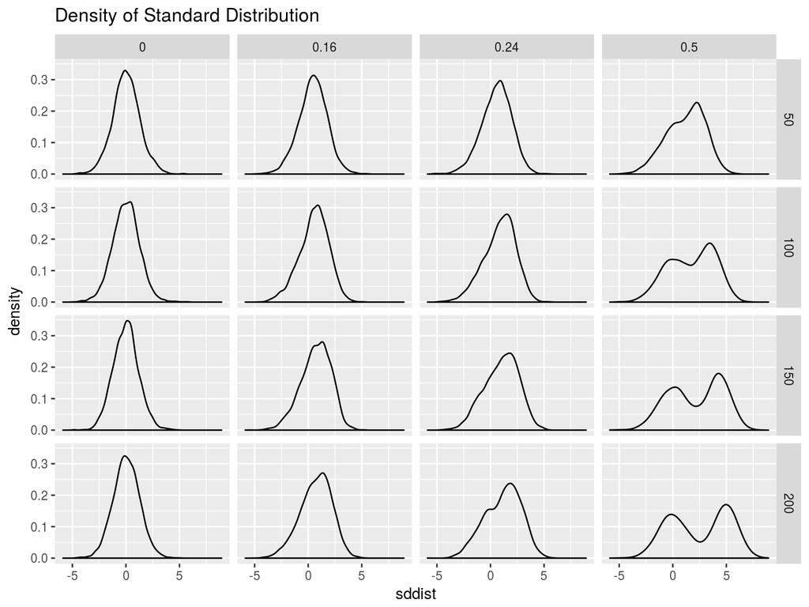

When $\beta = 0$, the restricted model and unrestricted estimate of $\hat\alpha$ are both centered around the true value of $\alpha$ so the standardized distribution, $\sqrt{n}(\hat\alpha - 0.2)$, is centered at 0.

As $\beta$ moves away from 0, we see a bimodal density as the restricted and unrestricted $\hat\alpha$ diverge.

# Density of the Estimators

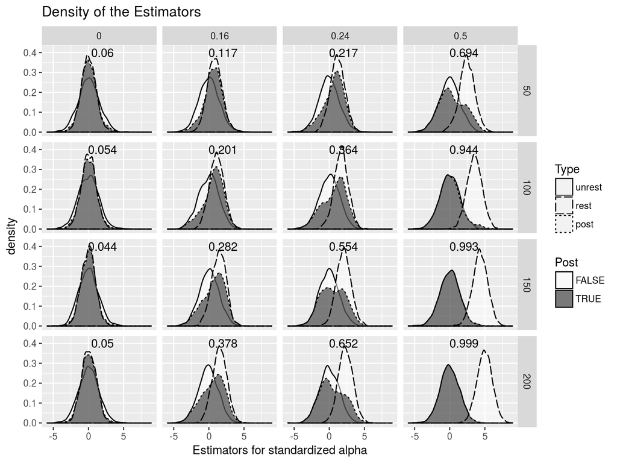